# BE vs ML results

2023-02-07

## Conditions

| Conditions | Values |
| --- | --- |
| N_sample | 100, 300, 500 |
| N_Items | 20, 40, 80 |
| r^2 of Cov on LV | 0.1, 0.5 |
| Method | BE_D, BE_MI, BE_I, BE_M, MLE |

- Pirors
  - BE_D: Diffuse prior for all parameters (Uniform)
  - BE_MI: Informative prior for only measurement params (Normal, LogN)
  - BE_I: Informative prior for all params
  - BE_M: Matched Informative prior for all params
- For matching the proportion of explained variance in the latent factor (i.e., 0.1 and 0.5), I changed the covariate effects on the latent factor and the outcome
  - In the 0.1 explained variance condition, X1 and X2 have `c(-0.2, 0.5)`, and for 0.5 condition, `c(-0.67, 0.50)`.
  - The size of covariate effects on the outcome was changed to `c(0.40, 0.3)` (`c(0.37, 0.3)`) to match 20% explained variance of the outcome.
  - With these values, all coefficients can be considered *standardized*, because all the variables in the model including the latent factor and the outcome have approximately the mean of zero and the variance of 1.
  - See the ‘check Data generation’ section below.
- 100 replications per condition

## Non-convergence

- nConv : Converged replications
- nWarn : replications with warnings (for Bayes, the replications with 1.1 < Rhat < 1.2)
- nError : Errors, non-convergence (no output at all in mplus; for Bayes, the replications with Rhat > 1.2)

|  | esttype | nsample | nitem | power_cov_on_lv | nConv | nWarn | nError |
| --- | --- | --- | --- | --- | --- | --- | --- |
| 1 | BE_D | 100 | 20 | 0.1 | 97 | 2 | 2 |
| 2 | BE_D | 100 | 20 | 0.5 | 90 | 7 | 7 |
| 3 | BE_D | 100 | 40 | 0.1 | 91 | 7 | 7 |
| 4 | BE_D | 100 | 40 | 0.5 | 90 | 7 | 7 |
| 5 | BE_D | 100 | 80 | 0.1 | 87 | 11 | 11 |
| 6 | BE_D | 100 | 80 | 0.5 | 82 | 14 | 14 |
| 7 | BE_D | 300 | 20 | 0.1 | 84 | 14 | 14 |
| 8 | BE_D | 300 | 20 | 0.5 | 68 | 24 | 24 |
| 9 | BE_D | 300 | 40 | 0.1 | 48 | 42 | 42 |
| 10 | BE_D | 300 | 40 | 0.5 | 59 | 24 | 24 |

[output cut: 80 more lines]

## Coverage

| nsample | nitem | powerOnlv | b1_BE_D | b1_BE_MI | b1_BE_I | b1_BE_M | b1_ML | b0_BE_D | b0_BE_MI | b0_BE_I | b0_BE_M | b0_ML | a1_BE_D | a1_BE_MI | a1_BE_I | a1_BE_M | a1_ML | tau_BE_D | tau_BE_MI | tau_BE_I | tau_BE_M | tau_ML | lambda_BE_D | lambda_BE_MI | lambda_BE_I | lambda_BE_M | lambda_ML |
| --- | --- | --- | --- | --- | --- | --- | --- | --- | --- | --- | --- | --- | --- | --- | --- | --- | --- | --- | --- | --- | --- | --- | --- | --- | --- | --- | --- |
| 100 | 20 | 0.1 | 0.990 | 0.980 | 0.98 | 1.00 | 0.840 | 1.000 | 0.980 | 0.98 | 0.98 | 0.940 | 1.000 | 0.990 | 0.99 | 1.00 | 0.820 | 0.967 | 0.963 | 0.964 | 0.959 | 0.968 | 0.886 | 0.994 | 0.995 | 0.988 | 0.881 |
|  |  | 0.5 | 0.938 | 0.937 | 0.95 | 0.98 | 0.950 | 0.979 | 0.947 | 0.93 | 0.95 | 0.890 | 0.969 | 0.968 | 0.99 | 1.00 | 0.980 | 0.945 | 0.969 | 0.970 | 0.969 | 0.968 | 0.862 | 0.989 | 0.990 | 0.994 | 0.916 |
|  | 40 | 0.1 | 0.990 | 0.990 | 0.99 | 0.99 | 0.815 | 1.000 | 0.990 | 0.99 | 1.00 | 0.988 | 1.000 | 0.990 | 0.99 | 1.00 | 0.802 | 0.973 | 0.962 | 0.962 | 0.961 | 0.969 | 0.830 | 0.989 | 0.990 | 0.989 | 0.898 |
|  |  | 0.5 | 0.948 | 0.960 | 0.96 | 0.97 | 0.968 | 0.979 | 0.930 | 0.93 | 0.96 | 0.926 | 0.979 | 0.980 | 0.99 | 1.00 | 0.957 | 0.948 | 0.960 | 0.960 | 0.957 | 0.965 | 0.828 | 0.986 | 0.987 | 0.991 | 0.942 |
|  | 80 | 0.1 | 0.980 | 0.980 | 0.99 | 1.00 | 0.881 | 1.000 | 1.000 | 0.99 | 1.00 | 0.964 | 0.990 | 0.990 | 0.99 | 1.00 | 0.905 | 0.965 | 0.964 | 0.966 | 0.961 | 0.961 | 0.789 | 0.982 | 0.982 | 0.988 | 0.828 |
|  |  | 0.5 | 0.958 | 0.960 | 0.97 | 0.99 | 0.975 | 1.000 | 0.950 | 0.95 | 0.97 | 0.951 | 0.948 | 0.950 | 0.98 | 1.00 | 0.963 | 0.958 | 0.961 | 0.961 | 0.961 | 0.975 | 0.784 | 0.981 | 0.981 | 0.988 | 0.895 |
| 300 | 20 | 0.1 | 1.000 | 0.980 | 0.98 | 0.98 | 0.860 | 1.000 | 0.980 | 0.98 | 0.99 | 0.910 | 1.000 | 1.000 | 1.00 | 1.00 | 0.880 | 0.951 | 0.963 | 0.965 | 0.966 | 0.959 | 0.628 | 0.973 | 0.974 | 0.983 | 0.945 |
|  |  | 0.5 | 0.891 | 0.970 | 0.98 | 0.99 | 0.990 | 0.957 | 0.980 | 0.98 | 0.99 | 0.930 | 0.935 | 0.970 | 0.98 | 0.99 | 0.970 | 0.929 | 0.955 | 0.955 | 0.958 | 0.950 | 0.570 | 0.978 | 0.978 | 0.979 | 0.941 |
|  | 40 | 0.1 | 0.978 | 0.990 | 0.99 | 0.99 | 0.880 | 1.000 | 0.950 | 0.94 | 0.96 | 0.910 | 0.989 | 0.990 | 0.99 | 0.99 | 0.880 | 0.947 | 0.962 | 0.961 | 0.960 | 0.961 | 0.491 | 0.970 | 0.970 | 0.984 | 0.949 |
|  |  | 0.5 | 0.843 | 0.990 | 0.99 | 0.99 | 0.980 | 0.964 | 0.930 | 0.94 | 0.93 | 0.940 | 0.952 | 1.000 | 1.00 | 1.00 | 1.000 | 0.940 | 0.954 | 0.955 | 0.957 | 0.963 | 0.483 | 0.967 | 0.970 | 0.976 | 0.954 |
|  | 80 | 0.1 | 0.988 | 0.990 | 0.99 | 1.00 | 0.830 | 1.000 | 0.970 | 0.97 | 0.97 | 0.915 | 0.988 | 1.000 | 1.00 | 1.00 | 0.798 | 0.883 | 0.951 | 0.951 | 0.952 | 0.903 | 0.406 | 0.971 | 0.969 | 0.980 | 0.628 |
|  |  | 0.5 | 0.812 | 0.960 | 0.95 | 0.96 | 0.944 | 0.928 | 0.950 | 0.96 | 0.95 | 0.956 | 0.812 | 0.940 | 0.96 | 0.98 | 0.967 | 0.901 | 0.951 | 0.952 | 0.956 | 0.957 | 0.403 | 0.966 | 0.966 | 0.978 | 0.877 |
| 500 | 20 | 0.1 | 0.978 | 0.970 | 0.97 | 0.98 | 0.930 | 0.978 | 0.970 | 0.97 | 0.96 | 0.940 | 0.957 | 0.990 | 0.99 | 0.99 | 0.930 | 0.908 | 0.951 | 0.952 | 0.962 | 0.964 | 0.435 | 0.972 | 0.972 | 0.976 | 0.929 |
|  |  | 0.5 | 0.817 | 0.980 | 0.99 | 0.99 | 0.990 | 0.968 | 0.980 | 0.97 | 0.97 | 0.950 | 0.892 | 0.980 | 0.98 | 0.99 | 0.940 | 0.887 | 0.951 | 0.948 | 0.959 | 0.956 | 0.378 | 0.978 | 0.978 | 0.984 | 0.950 |
|  | 40 | 0.1 | 0.966 | 0.990 | 0.98 | 1.00 | 0.910 | 0.977 | 0.980 | 0.98 | 0.99 | 0.950 | 0.954 | 0.990 | 0.97 | 0.99 | 0.900 | 0.901 | 0.957 | 0.958 | 0.961 | 0.957 | 0.277 | 0.968 | 0.969 | 0.975 | 0.944 |
|  |  | 0.5 | 0.852 | 0.940 | 0.95 | 0.95 | 0.930 | 0.975 | 0.950 | 0.95 | 0.95 | 0.910 | 0.864 | 0.940 | 0.95 | 0.96 | 0.920 | 0.907 | 0.958 | 0.959 | 0.958 | 0.959 | 0.261 | 0.966 | 0.967 | 0.975 | 0.937 |
|  | 80 | 0.1 | 0.948 | 0.960 | 0.96 | 0.99 | 0.890 | 0.983 | 0.980 | 0.98 | 0.98 | 0.950 | 0.931 | 0.960 | 0.97 | 0.99 | 0.890 | 0.875 | 0.952 | 0.952 | 0.954 | 0.956 | 0.203 | 0.968 | 0.969 | 0.972 | 0.957 |
|  |  | 0.5 | 0.758 | 0.940 | 0.94 | 0.95 | 0.950 | 0.903 | 0.940 | 0.93 | 0.94 | 0.930 | 0.790 | 0.980 | 0.98 | 1.00 | 0.960 | 0.799 | 0.955 | 0.955 | 0.956 | 0.957 | 0.203 | 0.965 | 0.966 | 0.971 | 0.948 |

## Bias

- Each dot indicates errors (estimate - true) of each replication.
- Item slopes and intercepts are averaged
- SE: Standard Errors for ML / Standard deviations for Bayes
- Red dot indicates the bias (the mean of errors)
- All non-converged replications are excluded (For Bayes, the replications with Rhat < 1.2 are used (not 1.1))

| nsample | nitem | powerOnlv | lambda_BE_D | lambda_BE_MI | lambda_BE_I | lambda_BE_M | lambda_ML | tau_BE_D | tau_BE_MI | tau_BE_I | tau_BE_M | tau_ML |
| --- | --- | --- | --- | --- | --- | --- | --- | --- | --- | --- | --- | --- |
| 100 | 20 | 0.1 | 1.921 | 0.071 | 0.074 | 0.010 | 0.927 | 0.898 | 0.033 | 0.031 | 0.028 | 0.069 |
|  |  | 0.5 | 2.040 | 0.058 | 0.065 | 0.006 | 1.497 | 1.349 | 0.029 | 0.025 | 0.018 | 0.055 |
|  | 40 | 0.1 | 2.293 | 0.074 | 0.074 | 0.010 | 1.274 | 0.934 | 0.023 | 0.022 | 0.019 | 0.069 |
|  |  | 0.5 | 2.315 | 0.066 | 0.068 | 0.007 | 0.659 | 1.458 | 0.021 | 0.020 | 0.018 | 0.027 |
|  | 80 | 0.1 | 2.456 | 0.075 | 0.074 | 0.010 | 0.707 | 1.022 | 0.010 | 0.009 | 0.008 | 0.122 |
|  |  | 0.5 | 2.448 | 0.070 | 0.071 | 0.008 | 0.736 | 1.176 | 0.010 | 0.009 | 0.008 | 0.158 |
| 300 | 20 | 0.1 | 2.542 | 0.030 | 0.031 | 0.009 | 0.192 | 0.389 | 0.026 | 0.024 | 0.022 | 0.013 |
|  |  | 0.5 | 2.766 | 0.025 | 0.027 | 0.004 | 0.278 | 0.707 | 0.033 | 0.032 | 0.027 | 0.011 |
|  | 40 | 0.1 | 3.058 | 0.013 | 0.014 | 0.008 | 0.175 | 0.518 | 0.018 | 0.018 | 0.016 | 0.015 |
|  |  | 0.5 | 3.125 | 0.014 | 0.014 | 0.005 | 0.129 | 0.537 | 0.017 | 0.017 | 0.014 | 0.008 |
|  | 80 | 0.1 | 3.464 | 0.009 | 0.009 | 0.008 | 0.251 | 0.810 | 0.012 | 0.012 | 0.011 | 0.050 |
|  |  | 0.5 | 3.481 | 0.012 | 0.012 | 0.007 | 0.223 | 0.646 | 0.008 | 0.008 | 0.008 | 0.012 |
| 500 | 20 | 0.1 | 2.930 | 0.019 | 0.018 | 0.006 | 0.084 | 0.381 | 0.021 | 0.020 | 0.019 | 0.008 |
|  |  | 0.5 | 3.102 | 0.017 | 0.017 | 0.002 | 0.068 | 0.425 | 0.023 | 0.023 | 0.021 | 0.007 |
|  | 40 | 0.1 | 3.606 | 0.007 | 0.006 | 0.006 | 0.037 | 0.414 | 0.015 | 0.015 | 0.014 | 0.007 |
|  |  | 0.5 | 3.638 | 0.008 | 0.008 | 0.004 | 0.035 | 0.421 | 0.014 | 0.013 | 0.014 | 0.005 |
|  | 80 | 0.1 | 4.025 | 0.004 | 0.003 | 0.008 | 0.055 | 0.496 | 0.007 | 0.007 | 0.007 | 0.007 |
|  |  | 0.5 | 3.998 | 0.004 | 0.004 | 0.006 | 0.077 | 0.719 | 0.008 | 0.008 | 0.008 | 0.004 |

| nsample | nitem | powerOnlv | b0_BE_D | b0_BE_MI | b0_BE_I | b0_BE_M | b0_ML | b1_BE_D | b1_BE_MI | b1_BE_I | b1_BE_M | b1_ML | a1_BE_D | a1_BE_MI | a1_BE_I | a1_BE_M | a1_ML |
| --- | --- | --- | --- | --- | --- | --- | --- | --- | --- | --- | --- | --- | --- | --- | --- | --- | --- |
| 100 | 20 | 0.1 | 0.069 | 0.037 | 0.031 | 0.023 | 0.040 | 0.257 | 0.113 | 0.077 | 0.027 | 0.303 | 0.259 | 0.162 | 0.074 | 0.019 | 0.283 |
|  |  | 0.5 | 0.120 | 0.050 | 0.044 | 0.031 | 0.046 | 0.257 | 0.078 | 0.051 | 0.023 | 0.230 | 0.621 | 0.412 | 0.094 | 0.021 | 0.332 |
|  | 40 | 0.1 | 0.068 | 0.034 | 0.030 | 0.023 | 0.036 | 0.232 | 0.087 | 0.069 | 0.023 | 0.460 | 0.195 | 0.077 | 0.063 | 0.017 | 0.487 |
|  |  | 0.5 | 0.161 | 0.049 | 0.044 | 0.032 | 0.045 | 0.300 | 0.085 | 0.064 | 0.027 | 0.186 | 0.442 | 0.201 | 0.091 | 0.022 | 0.235 |
|  | 80 | 0.1 | 0.066 | 0.037 | 0.033 | 0.024 | 0.049 | 0.272 | 0.090 | 0.071 | 0.024 | 0.247 | 0.204 | 0.078 | 0.065 | 0.018 | 0.266 |
|  |  | 0.5 | 0.113 | 0.043 | 0.036 | 0.027 | 0.039 | 0.311 | 0.085 | 0.061 | 0.024 | 0.159 | 0.420 | 0.117 | 0.083 | 0.022 | 0.255 |
| 300 | 20 | 0.1 | 0.039 | 0.016 | 0.015 | 0.012 | 0.018 | 0.202 | 0.053 | 0.048 | 0.023 | 0.103 | 0.122 | 0.041 | 0.038 | 0.016 | 0.096 |
|  |  | 0.5 | 0.050 | 0.013 | 0.012 | 0.010 | 0.012 | 0.223 | 0.024 | 0.021 | 0.012 | 0.043 | 0.395 | 0.072 | 0.041 | 0.017 | 0.057 |
|  | 40 | 0.1 | 0.032 | 0.014 | 0.013 | 0.011 | 0.015 | 0.162 | 0.042 | 0.040 | 0.018 | 0.097 | 0.146 | 0.044 | 0.042 | 0.018 | 0.106 |
|  |  | 0.5 | 0.043 | 0.015 | 0.014 | 0.013 | 0.014 | 0.193 | 0.017 | 0.016 | 0.011 | 0.021 | 0.228 | 0.026 | 0.024 | 0.012 | 0.029 |
|  | 80 | 0.1 | 0.058 | 0.015 | 0.014 | 0.012 | 0.016 | 0.188 | 0.035 | 0.033 | 0.017 | 0.074 | 0.159 | 0.032 | 0.033 | 0.015 | 0.067 |
|  |  | 0.5 | 0.066 | 0.013 | 0.012 | 0.011 | 0.011 | 0.304 | 0.026 | 0.024 | 0.016 | 0.039 | 0.388 | 0.040 | 0.035 | 0.019 | 0.063 |
| 500 | 20 | 0.1 | 0.029 | 0.010 | 0.010 | 0.009 | 0.011 | 0.164 | 0.029 | 0.026 | 0.016 | 0.052 | 0.152 | 0.028 | 0.026 | 0.015 | 0.054 |
|  |  | 0.5 | 0.024 | 0.008 | 0.008 | 0.007 | 0.007 | 0.186 | 0.012 | 0.011 | 0.008 | 0.014 | 0.235 | 0.022 | 0.021 | 0.012 | 0.025 |
|  | 40 | 0.1 | 0.044 | 0.008 | 0.007 | 0.007 | 0.008 | 0.204 | 0.026 | 0.025 | 0.014 | 0.050 | 0.195 | 0.030 | 0.029 | 0.017 | 0.056 |
|  |  | 0.5 | 0.030 | 0.010 | 0.010 | 0.009 | 0.010 | 0.203 | 0.014 | 0.013 | 0.010 | 0.015 | 0.281 | 0.031 | 0.029 | 0.018 | 0.028 |
|  | 80 | 0.1 | 0.038 | 0.008 | 0.008 | 0.006 | 0.009 | 0.306 | 0.033 | 0.031 | 0.018 | 0.060 | 0.302 | 0.035 | 0.033 | 0.018 | 0.062 |
|  |  | 0.5 | 0.054 | 0.008 | 0.008 | 0.008 | 0.009 | 0.251 | 0.014 | 0.013 | 0.011 | 0.020 | 0.275 | 0.019 | 0.018 | 0.013 | 0.027 |

### Item intercept (Tau)

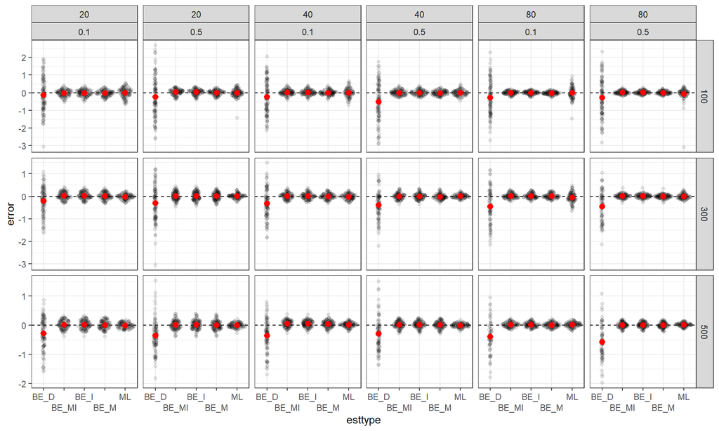

### Item Slope (Lambda)

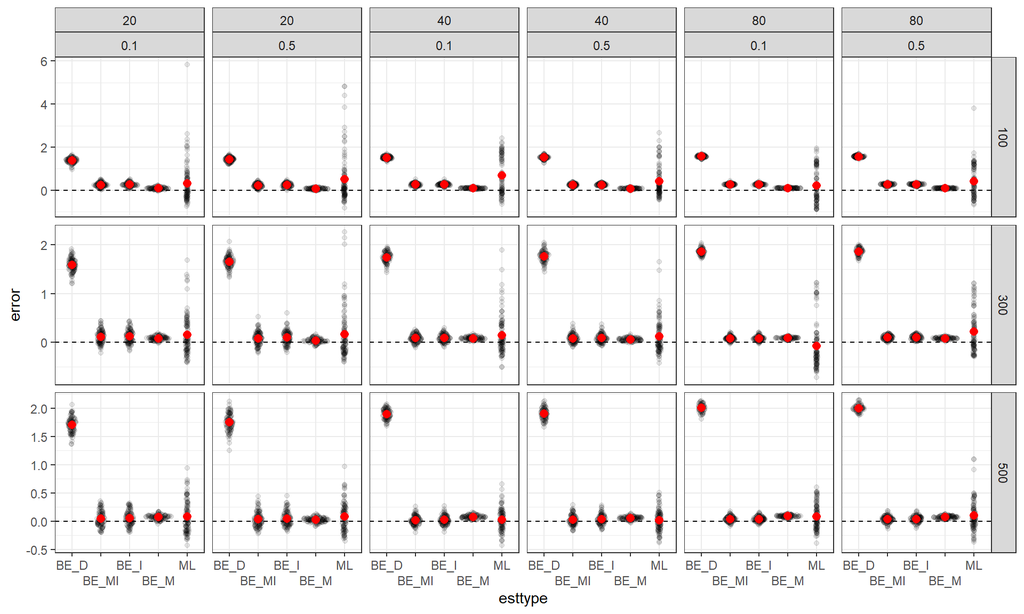

### Effect of latent factor on Y (Omega)

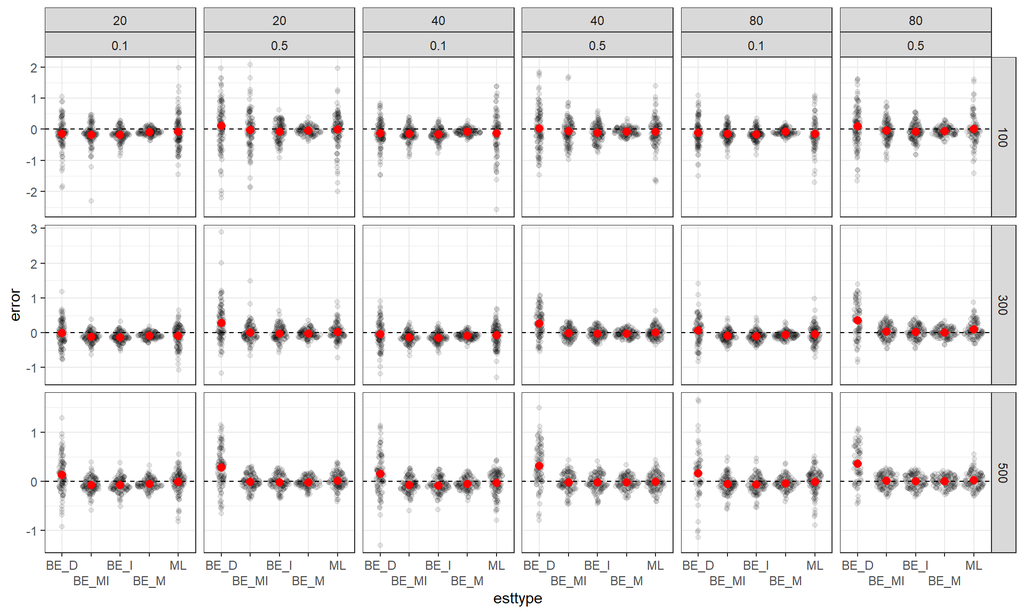

### Principal effects (b1)

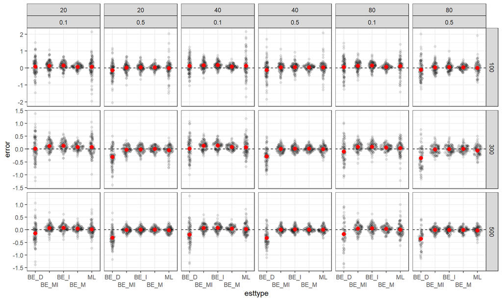

### Effects of Z on Y (b0)

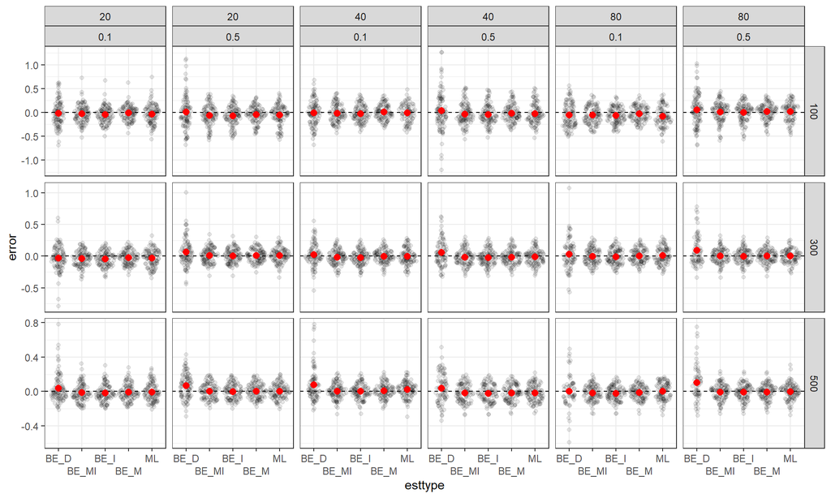

### Effects of covariates on latent factor (bu)

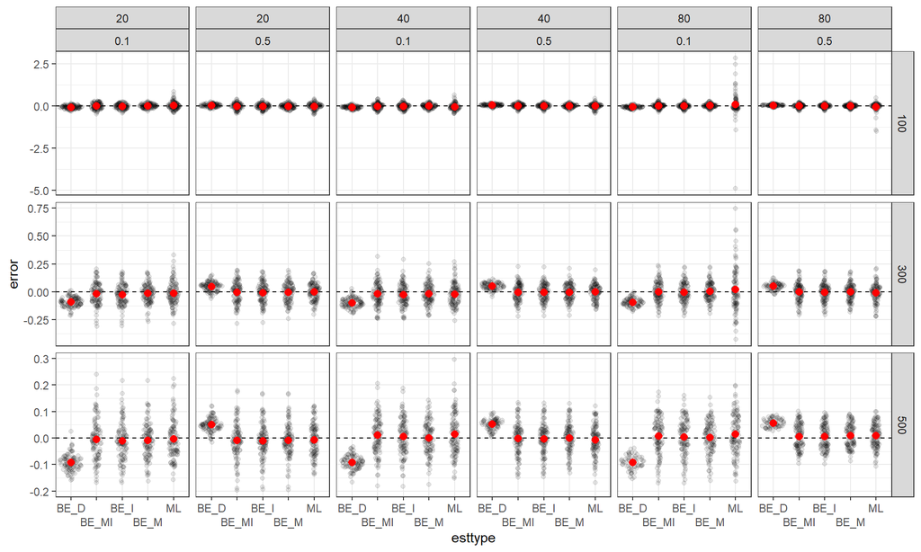

### Effects of covariates on Y (by)

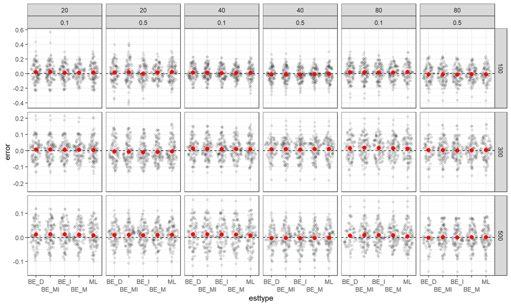

## MSE Ratio

- MSE ratio = MSE of ML / MSE of Bayesian
  - Higher MSE ratio -> better (smaller) MSE in Bayesian
- When MSE ratio = 1, no difference in MSE

MSE ratio of measurement part

| nsample | nitem | powerOnlv | ratio_D_lambda | ratio_MI_lambda | ratio_I_lambda | ratio_M_lambda | ratio_D_tau | ratio_MI_tau | ratio_I_tau | ratio_M_tau |
| --- | --- | --- | --- | --- | --- | --- | --- | --- | --- | --- |
| 100 | 20 | 0.1 | 0.483 | 13.038 | 12.482 | 89.435 | 0.077 | 2.094 | 2.251 | 2.450 |
|  |  | 0.5 | 0.734 | 26.017 | 22.984 | 240.296 | 0.040 | 1.871 | 2.141 | 3.001 |
|  | 40 | 0.1 | 0.556 | 17.177 | 17.232 | 128.071 | 0.074 | 2.993 | 3.144 | 3.555 |
|  |  | 0.5 | 0.285 | 9.974 | 9.696 | 90.861 | 0.018 | 1.243 | 1.300 | 1.455 |
|  | 80 | 0.1 | 0.288 | 9.470 | 9.574 | 68.040 | 0.119 | 12.804 | 13.114 | 14.488 |
|  |  | 0.5 | 0.301 | 10.505 | 10.414 | 87.029 | 0.134 | 16.320 | 16.763 | 19.132 |
| 300 | 20 | 0.1 | 0.076 | 6.325 | 6.196 | 21.943 | 0.034 | 0.516 | 0.543 | 0.601 |
|  |  | 0.5 | 0.101 | 10.986 | 10.118 | 79.251 | 0.016 | 0.333 | 0.348 | 0.405 |
|  | 40 | 0.1 | 0.057 | 13.199 | 12.538 | 22.267 | 0.029 | 0.809 | 0.837 | 0.951 |
|  |  | 0.5 | 0.041 | 9.204 | 9.012 | 26.539 | 0.014 | 0.441 | 0.449 | 0.528 |
|  | 80 | 0.1 | 0.072 | 29.094 | 28.749 | 30.749 | 0.062 | 4.156 | 4.192 | 4.721 |
|  |  | 0.5 | 0.064 | 18.706 | 17.887 | 30.658 | 0.018 | 1.373 | 1.427 | 1.501 |
| 500 | 20 | 0.1 | 0.029 | 4.437 | 4.630 | 13.197 | 0.022 | 0.397 | 0.419 | 0.448 |
|  |  | 0.5 | 0.022 | 3.910 | 4.057 | 29.773 | 0.015 | 0.282 | 0.284 | 0.306 |
|  | 40 | 0.1 | 0.010 | 5.680 | 5.810 | 5.836 | 0.018 | 0.476 | 0.494 | 0.526 |
|  |  | 0.5 | 0.010 | 4.180 | 4.283 | 9.569 | 0.012 | 0.361 | 0.380 | 0.366 |
|  | 80 | 0.1 | 0.014 | 15.139 | 15.912 | 6.739 | 0.014 | 0.954 | 0.973 | 0.988 |
|  |  | 0.5 | 0.019 | 18.617 | 17.702 | 13.709 | 0.006 | 0.483 | 0.498 | 0.499 |

| nsample | nitem | powerOnlv | ratio_D_b0 | ratio_MI_b0 | ratio_I_b0 | ratio_M_b0 | ratio_D_b1 | ratio_MI_b1 | ratio_I_b1 | ratio_M_b1 | ratio_D_a1 | ratio_MI_a1 | ratio_I_a1 | ratio_M_a1 |
| --- | --- | --- | --- | --- | --- | --- | --- | --- | --- | --- | --- | --- | --- | --- |
| 100 | 20 | 0.1 | 0.588 | 1.077 | 1.284 | 1.761 | 1.183 | 2.682 | 3.953 | 11.047 | 1.092 | 1.743 | 3.826 | 14.580 |
|  |  | 0.5 | 0.385 | 0.916 | 1.045 | 1.472 | 0.893 | 2.956 | 4.508 | 9.983 | 0.534 | 0.805 | 3.511 | 16.022 |
|  | 40 | 0.1 | 0.533 | 1.056 | 1.214 | 1.561 | 1.986 | 5.266 | 6.685 | 19.597 | 2.499 | 6.290 | 7.777 | 28.059 |
|  |  | 0.5 | 0.280 | 0.919 | 1.029 | 1.416 | 0.618 | 2.194 | 2.914 | 6.958 | 0.530 | 1.167 | 2.574 | 10.637 |
|  | 80 | 0.1 | 0.746 | 1.340 | 1.484 | 2.084 | 0.907 | 2.755 | 3.490 | 10.398 | 1.303 | 3.406 | 4.096 | 14.982 |
|  |  | 0.5 | 0.348 | 0.909 | 1.083 | 1.453 | 0.511 | 1.871 | 2.590 | 6.678 | 0.608 | 2.181 | 3.088 | 11.460 |
| 300 | 20 | 0.1 | 0.451 | 1.121 | 1.215 | 1.528 | 0.511 | 1.933 | 2.159 | 4.412 | 0.780 | 2.340 | 2.518 | 5.838 |
|  |  | 0.5 | 0.245 | 0.951 | 1.038 | 1.214 | 0.193 | 1.783 | 2.083 | 3.621 | 0.145 | 0.792 | 1.383 | 3.436 |
|  | 40 | 0.1 | 0.463 | 1.092 | 1.140 | 1.400 | 0.596 | 2.308 | 2.411 | 5.331 | 0.730 | 2.439 | 2.524 | 5.937 |
|  |  | 0.5 | 0.324 | 0.954 | 0.981 | 1.070 | 0.111 | 1.281 | 1.367 | 1.896 | 0.128 | 1.101 | 1.229 | 2.410 |
|  | 80 | 0.1 | 0.284 | 1.088 | 1.183 | 1.382 | 0.396 | 2.123 | 2.227 | 4.415 | 0.422 | 2.072 | 2.019 | 4.331 |
|  |  | 0.5 | 0.166 | 0.830 | 0.878 | 0.978 | 0.130 | 1.504 | 1.671 | 2.489 | 0.162 | 1.561 | 1.789 | 3.277 |
| 500 | 20 | 0.1 | 0.375 | 1.027 | 1.105 | 1.223 | 0.317 | 1.792 | 2.014 | 3.192 | 0.355 | 1.902 | 2.080 | 3.690 |
|  |  | 0.5 | 0.294 | 0.911 | 0.939 | 1.004 | 0.073 | 1.181 | 1.254 | 1.720 | 0.106 | 1.120 | 1.205 | 2.163 |
|  | 40 | 0.1 | 0.190 | 1.053 | 1.109 | 1.225 | 0.243 | 1.896 | 1.975 | 3.429 | 0.287 | 1.865 | 1.911 | 3.232 |
|  |  | 0.5 | 0.329 | 0.944 | 0.970 | 1.084 | 0.073 | 1.067 | 1.119 | 1.521 | 0.098 | 0.902 | 0.958 | 1.540 |
|  | 80 | 0.1 | 0.239 | 1.148 | 1.182 | 1.461 | 0.197 | 1.824 | 1.973 | 3.440 | 0.206 | 1.777 | 1.898 | 3.369 |
|  |  | 0.5 | 0.159 | 1.014 | 1.037 | 1.113 | 0.080 | 1.484 | 1.549 | 1.861 | 0.097 | 1.384 | 1.448 | 2.038 |

### Item intercept (tau)

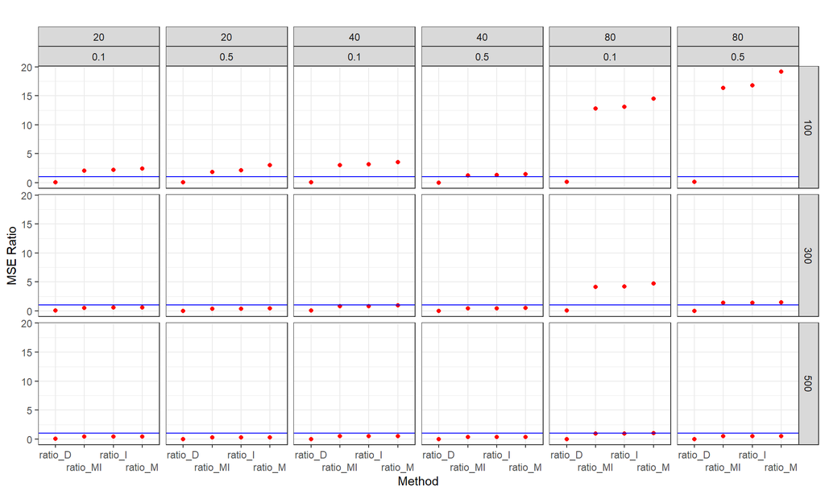

### Item Slope (lambda)

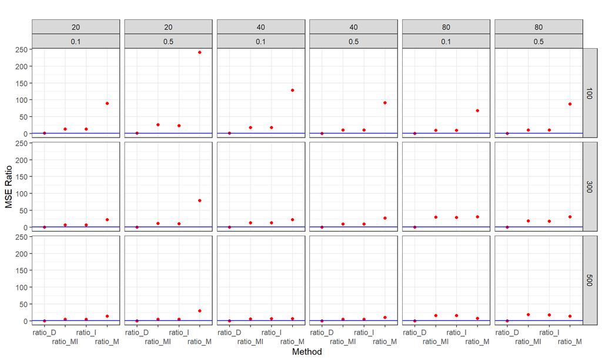

### Effect of latent factor on Y (Omega)

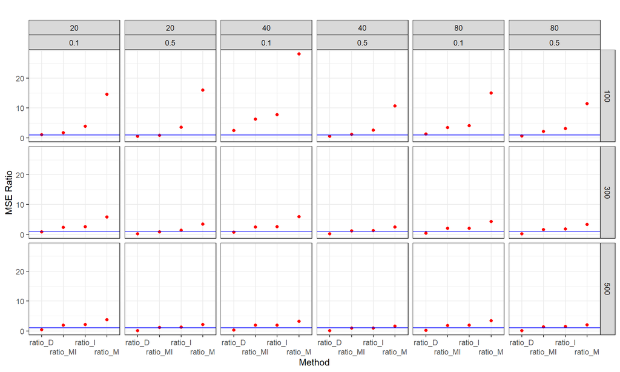

### Principal effects (b1)

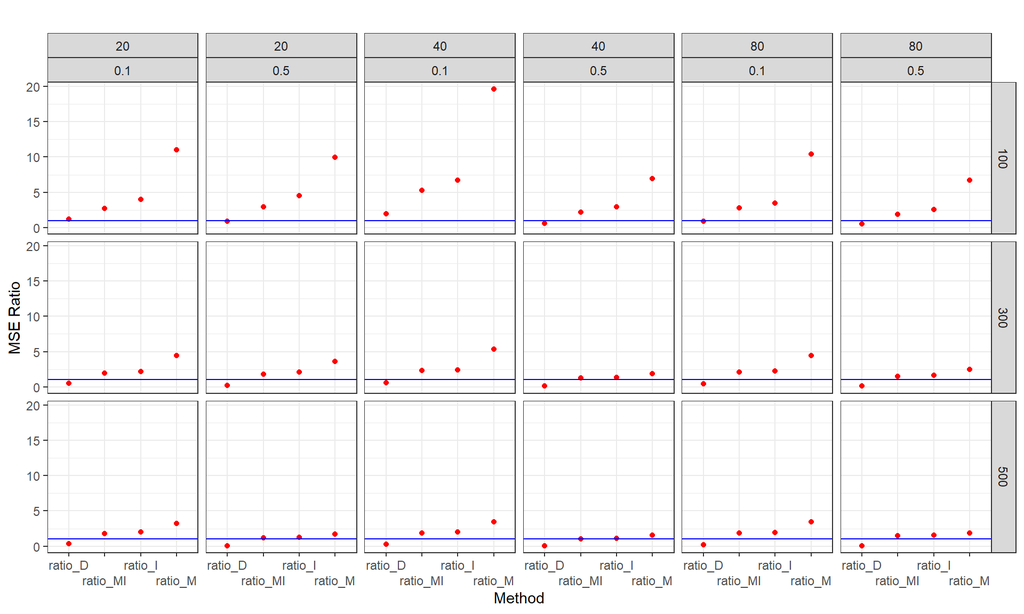

### Effects of Z on Y (b0)

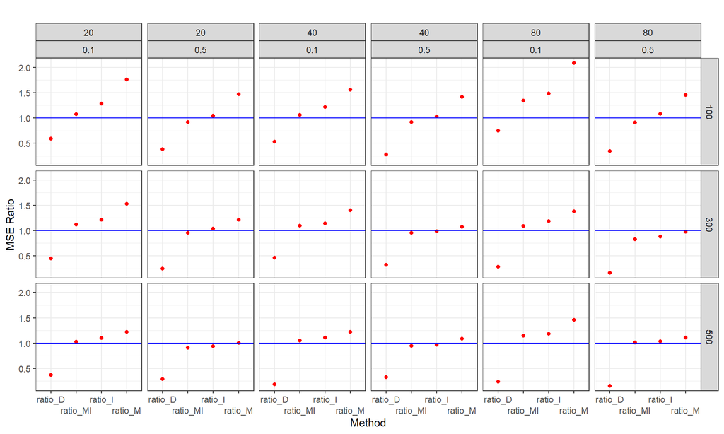

### Effects of covariates on latent factor (bu)

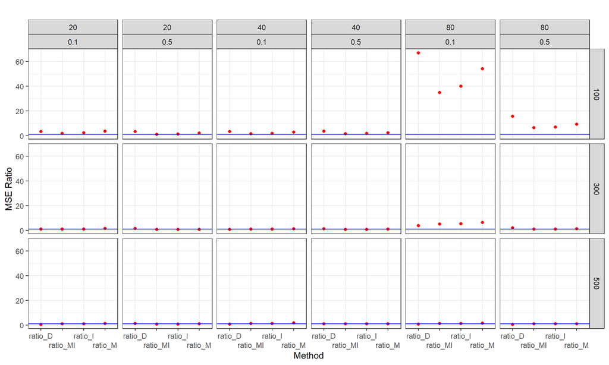

### Effects of covariates on Y (by)

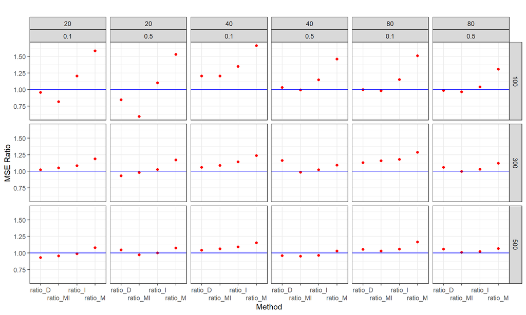